# Simulating Field Trial Data and Visualising Spatial Patterns

Usage guide for `simulate_spatial_data.R`

14 March 2026

## 1 Overview

`simulate_spatial_data.R` provides three functions for generating and visualising synthetic multi-environment field trial data. The simulated data is intended as a test input for the spatial correction pipeline in `fit_spatial_models.R`.

**Experimental design simulated:**

- Unreplicated multi-bench trial: each genotype appears once per bench
- Each bench is laid out on a regular row × column grid
- The observed phenotype is the sum of a true genotype effect, a configurable spatial environmental gradient, and random plot-level noise

**Functions provided:**

| Function | Purpose |
| --- | --- |
| `simulate_field_trial()` | Generate a synthetic dataset |
| `plot_bench_heatmap()` | Heatmap for a single bench |
| `plot_all_bench_heatmaps()` | Composite heatmap for all benches, saved as PNG |

## 2 Setup

Source the script to load all three functions into your session.

## 3 Function reference

### 3.1 `simulate_field_trial()`

Generates a complete multi-bench dataset. Returns a list with three elements:

- `$data`: the plot-level data frame (`Bench`, `Genotype`, `Row`, `Col`, `True_Spatial`, `<pheno_name>`)
- `$true_effects`: the underlying genotype effects used to generate the data (`Genotype`, `True_<pheno_name>`)
- `$pheno_name`: the name of the phenotype column (useful for passing to plot functions)

#### 3.1.1 Parameters

The number of genotypes is always derived as `n_rows × n_cols`, giving exactly one replicate per genotype per bench. There is no `n_geno` argument; changing bench dimensions automatically sets the number of genotypes.

[output not shown]

#### 3.1.2 Spatial pattern types (`spatial_type`)

[output not shown]

**Centring:** All types except type 1 are centred to mean zero per bench (`raw - mean(raw)`). This ensures the spatial component represents deviations from the bench mean rather than an absolute level shift, which is the correct parameterisation for joint multi-bench models where the spatial smooth is zero-mean constrained.

The data-generating model for each plot is:

$$y_{ij} = g_i + s_j +
\varepsilon_{ij}$$

where $g_i \sim N(\mu_g, \sigma_g^2)$ clipped to [`pheno_min`, `pheno_max`] is the true genotype effect (`mean_pheno`, `sd_geno`), $s_j$ is the spatial contribution at plot $j$ (determined by `spatial_type` and `spatial_intensity`, centred to mean zero), and $\varepsilon_{ij} \sim N(0, \sigma_e^2)$ is random plot-level noise (`sd_error`). The true genotype effects $g_i$ are stored in `$true_effects`, and the per-plot spatial contributions are stored in the `True_Spatial` column of `$data`. Both are used after spatial correction to validate BLUE/BLUP recovery via Pearson correlation and RMSE. When `save_csv = TRUE` (default), `<pheno_name>_simulation.csv` and `<pheno_name>_true_effects.csv` are written automatically to `output_dir`.

### 3.2 `plot_bench_heatmap()`

Plots the field layout for a **single bench** as a coloured tile grid. Returns a `ggplot` object that can be further customised with `ggplot2` layers or composed into multi-panel figures with `patchwork`.

#### 3.2.1 Parameters

| Parameter | Default | Description |
| --- | --- | --- |
| `bench_dfr` | none | Data frame containing the bench data. Pass the full dataset when using `bench`, or a pre-subsetted single-bench frame when `bench = NULL`. |
| `pheno` | none | Name of the response column to use as the fill colour. |
| `rn` | `"Row"` | Name of the row position column. |
| `cn` | `"Col"` | Name of the column position column. |
| `gt` | `"Genotype"` | Name of the genotype column (only used when `show_labels = TRUE`). |
| `bench_col` | `"Bench"` | Name of the bench identifier column; used only when `bench` is specified. |
| `bench` | `NULL` | Bench identifier to select from `bench_dfr`. When set, the function subsets the data internally (no pre-filtering needed). |
| `bench_label` | `""` | Title displayed above the panel. Defaults to the `bench` value when `bench` is specified. |
| `show_labels` | `FALSE` | If `TRUE`, genotype names are printed inside each tile. |
| `shared_limits` | `NULL` | `c(min, max)` for the fill colour scale. Pass the global range across all benches to make scales comparable. `NULL` = auto-scale to this bench only. |
| `label_size` | `2.5` | Font size of genotype labels (in `ggplot2` units). |

**Axis orientation:** column 1 is at the left, last column at the right (x-axis, ascending). Row 1 is at the top, last row at the bottom (y-axis reversed to match field convention). This matches the physical layout of a bench when viewed from above.

### 3.3 `plot_all_bench_heatmaps()`

Loops over all benches, assembles panels with `patchwork`, and saves the composite figure as a PNG file.

#### 3.3.1 Parameters

| Parameter | Default | Description |
| --- | --- | --- |
| `dfr` | none | Full data frame (all benches). |
| `pheno` | none | Name of the response column. |
| `rn` | `"Row"` | Row column name. |
| `cn` | `"Col"` | Column column name. |
| `gt` | `"Genotype"` | Genotype column name. |
| `bench_col` | `"Bench"` | Column identifying the bench. |
| `show_labels` | `FALSE` | Show genotype names on tiles. |
| `shared_scale` | `TRUE` | Use a common colour scale across all benches. |
| `output_png` | `"heatmaps.png"` | Output file path. |
| `ncol_panels` | `2` | Number of bench panels per row in the composite. |
| `panel_width` | `7` | Width per panel in inches. |
| `panel_height` | `4` | Height per panel in inches. |
| `label_size` | `2.5` | Font size for genotype labels. |

## 4 Worked example

### 4.1 1. No spatial effect (type 1)

A baseline simulation with no environmental gradient. All observed variation reflects genotype differences and random plot noise only.

```
## Data written to:          data/BNI_simulation.csv
## True effects written to:  data/BNI_true_effects.csv
```

```
##    Bench Genotype Row Col True_Spatial      BNI
## 1 Bench1     G100   1   1            0 61.41083
## 2 Bench1     G198   2   1            0 68.17097
## 3 Bench1     G091   3   1            0 71.55242
## 4 Bench1     G212   4   1            0 85.83332
## 5 Bench1     G281   5   1            0 63.55455
## 6 Bench1     G024   6   1            0 71.99604
```

```
## Heatmap saved to: figures/heatmap_type1_none.png
```

### 4.2 2. Column gradient (type 3)

```
## Data written to:          data/BNI_simulation.csv
## True effects written to:  data/BNI_true_effects.csv
```

```
##    Bench Genotype Row Col True_Spatial      BNI
## 1 Bench1     G100   1   1    -18.95746 42.45337
## 2 Bench1     G198   2   1    -18.95746 49.21351
## 3 Bench1     G091   3   1    -18.95746 52.59496
## 4 Bench1     G212   4   1    -18.95746 66.87586
## 5 Bench1     G281   5   1    -18.95746 44.59709
## 6 Bench1     G024   6   1    -18.95746 53.03858
```

```
## Observations: 1200
```

```
## Genotypes:    300
```

```
## Benches:      4
```

```
## Heatmap saved to: figures/heatmap_type3_cols.png
```

Vertical bands of colour are visible, with the lowest values at column 1 and the highest at the last column, forming a clear monotonic column-wise gradient.

### 4.3 3. Multi-bench heatmaps

`plot_all_bench_heatmaps()` loops over all benches, assembles the panels with `patchwork`, and saves the result as a PNG. The key layout parameters are `ncol_panels` (bench panels per row), `panel_width`, and `panel_height`.

The default `ncol_panels = 2` arranges panels two-per-row, which is compact for reports:

```
## Heatmap saved to: figures/heatmap_type3_cols_2col.png
```

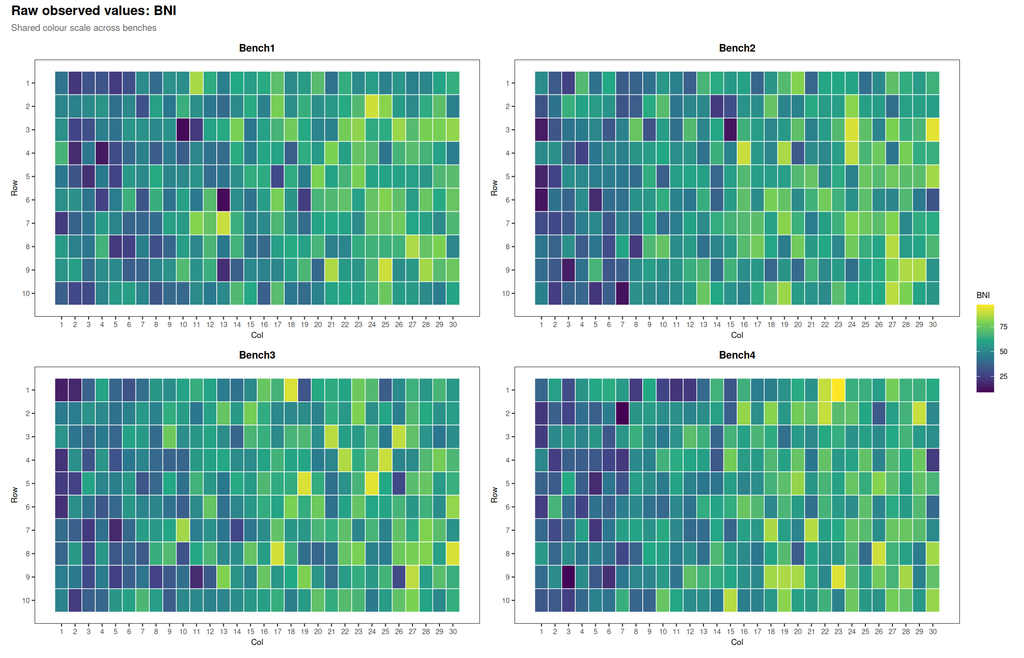

Setting `ncol_panels = 1` arranges benches in a single column so each fills the full width, which is useful when benches are wide (many columns) and side-by-side panels would be too narrow to read:

```
## Heatmap saved to: figures/heatmap_type3_cols_1col.png
```

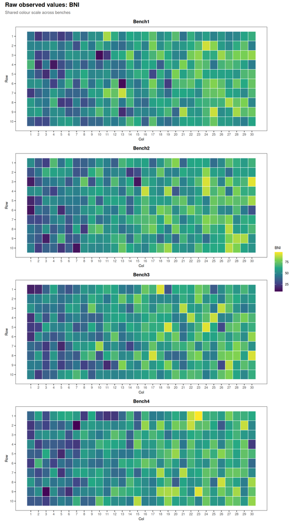

### 4.4 4. Plotting a single bench

`plot_bench_heatmap()` returns a `ggplot` object for a single bench, allowing further customisation or composition with `patchwork`. Pass the full dataset and specify `bench` to select which bench to plot (no pre-subsetting needed).

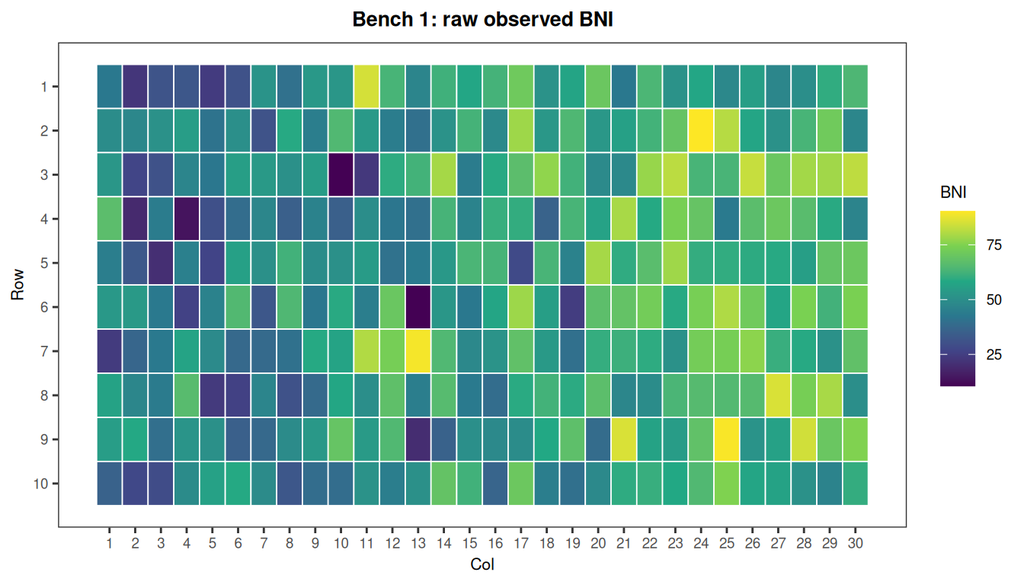

### 4.5 5. Adding genotype labels

Set `show_labels = TRUE` to print the genotype name inside each tile. Reduce `label_size` for large benches where tiles are narrow.

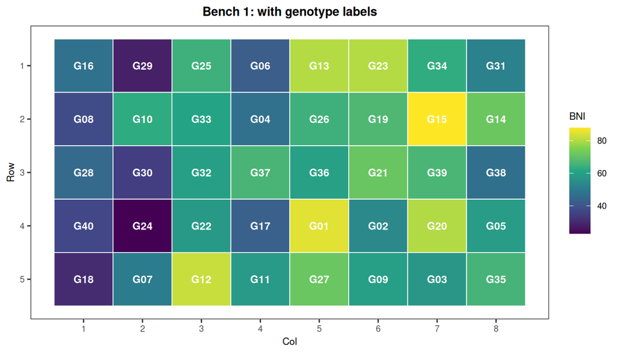

### 4.6 6. Shared vs independent colour scales

When `shared_scale = TRUE` (default), the fill colour maps to the global phenotype range across all benches, making values directly comparable between panels. When `shared_scale = FALSE`, each bench uses its own range, which can help reveal within-bench spatial structure when between-bench means differ.

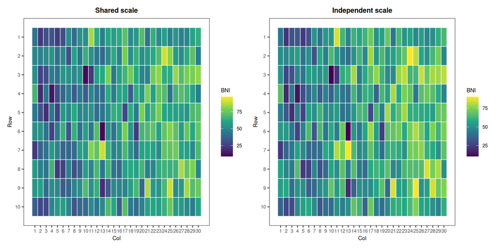

### 4.7 7. Edge effects and hotspot patterns (types 6 and 7)

Types 6 and 7 are more realistic patterns for glasshouse trials. Type 6 combines a border-proximity effect with a diagonal asymmetry (top-left elevated, bottom-right depressed). Type 7 places a compact Gaussian bell at an off-centre position mimicking a localised disturbance.

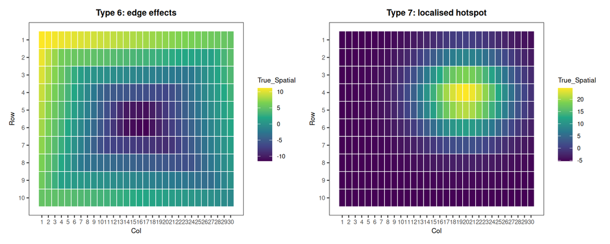

The edge-effect pattern is highest at all four borders and lowest in the interior, with a diagonal asymmetry (top-left corner is more elevated than bottom-right). The hotspot is a compact circular region in the upper-right quadrant; outside it the surface is slightly negative (because the pattern is centred to mean zero).

### 4.8 8. Per-bench spatial intensity

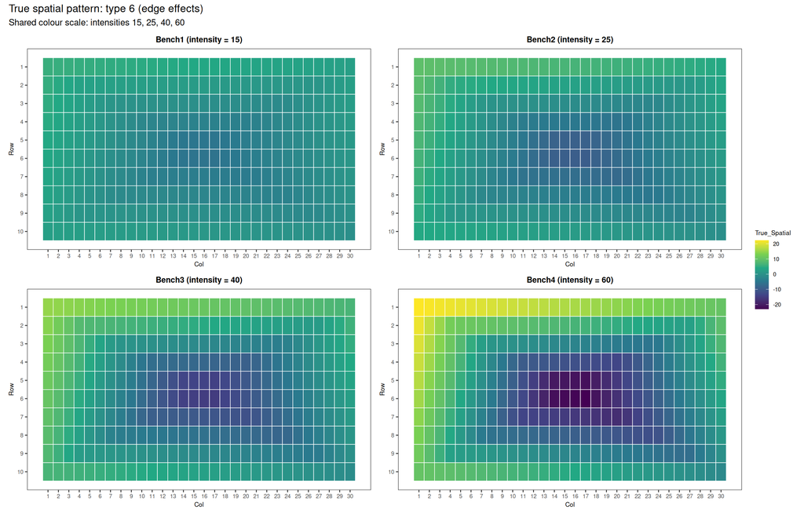

With a shared colour scale, the 4-fold increase in spatial severity from Bench1 to Bench4 is immediately visible.

### 4.9 9. Inspecting the true genotype effects

`$true_effects` contains the latent genotype values used to generate the data. After running `fit_spatial_models.R`, the Pearson correlation and RMSE between these true effects and the extracted BLUEs (or BLUPs) quantify how well the spatial correction has recovered the signal.

```
##   Genotype True_BNI
## 1     G001 71.45150
## 2     G002 48.22362
## 3     G003 59.35754
## 4     G004 62.59435
## 5     G005 59.85122
## 6     G006 53.72651
```

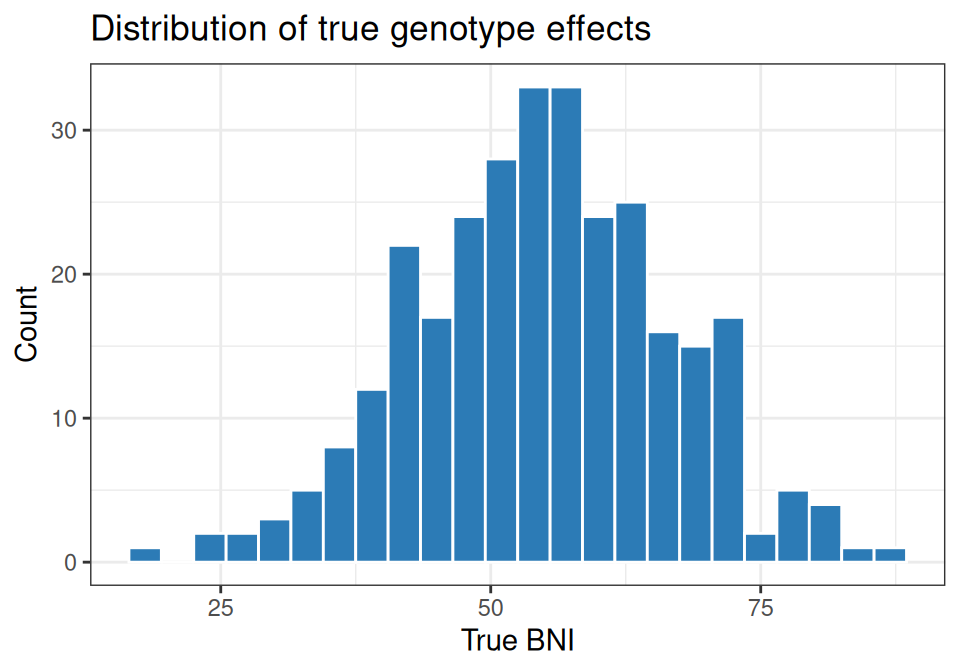

To visualise how true genotype values are arranged spatially across all benches, merge `$true_effects` with the plot-level data (which carries the Row, Col, and Bench positions) and pass the result to `plot_all_bench_heatmaps()`. Because genotypes are randomised independently per bench, the spatial pattern of true effects will differ between benches, confirming that the arrangement is random rather than structured.

```
## Heatmap saved to: figures/heatmap_true_effects.png
```

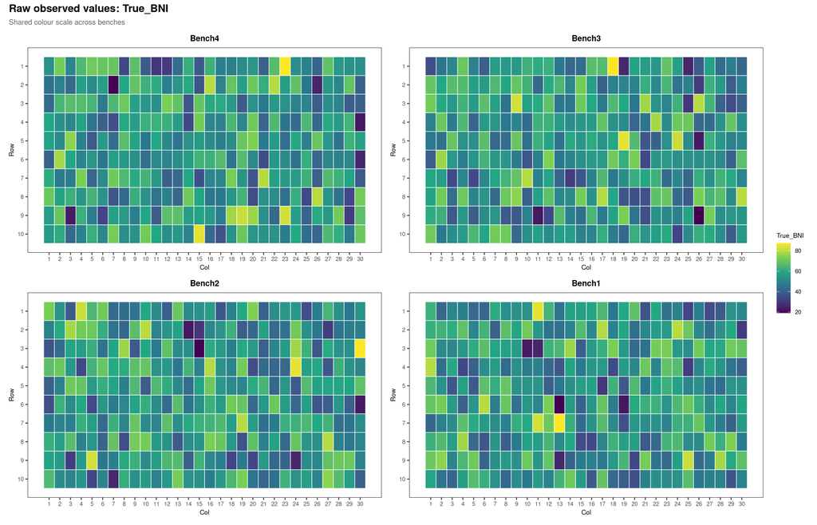

## 5 Saving outputs

### 5.1 Output files from this document

All files produced by knitting this document are written to `figures/` relative to the document location (i.e. `docs/figures/`):

[output not shown]

**Note:** Examples using `save_csv = FALSE` (sections 7–8) do not write CSV files.

### 5.2 Running the script directly

Running `simulate_spatial_data.R` directly with `Rscript` produces the following files in `data/` at the project root:

| File | Contents |
| --- | --- |
| `BNI_simulation.csv` | Plot-level data: Bench, Genotype, Row, Col, phenotype value |
| `BNI_true_effects.csv` | Latent genotype effects used to generate the data |
| `heatmaps_raw_labelled.png` | Composite heatmap with genotype names, shared colour scale |